# Women in Math, Stats, and CS –– Card Profiles

[figure not shown]

### Ada Lovelace (A)

Ada Lovelace was an mathematician from the 1800s. She is considered by many to be the first ever computer programmer for writing an algorithm for a computing machine called the [analytical engine](https://blogs.bodleian.ox.ac.uk/adalovelace/2018/07/26/ada-lovelace-and-the-analytical-engine/), which was developed by inventor Charles Babbage. Lovelace made notes on how the engine could be used to handle not just numbers, but letters and symbols, and also theorized the method of code looping. Her contributions had little to no impact while she was alive and were not known on a widespread scale until 1953, when her work was published by BV Bowden in [*Faster Than Thought: A Symposium on Digital Computing Machines*](https://doi.org/10.1002/qj.49708034340).

### Adele Goldberg (K)

Adele Goldberg is a computer scientist, known for being one of the creators of the programming language [Smalltalk-80](https://computerhistory.org/blog/introducing-the-smalltalk-zoo-48-years-of-smalltalk-history-at-chm/), which was influential in the development of many of the world’s top object-oriented programming languages today (Java, Python, Ruby, etc.). Smalltalk also proved to be a [key tool](https://theagilerevolution.com/tag/smalltalk/) in the development of the agile development methodology, which centers on the idea of iterative development.

### Anita Borg (Q)

Anita Borg was a computer scientist who founded the [Grace Hopper Celebration of Women in Computing](https://ghc.anitab.org)—an annual series of conferences designed to highlight the work of women in computing—and the [Institute for Women in Technology](https://anitab.org)—a nonprofit focused on recruiting and advancing women in the technology sector.

### Annie Easley (J)

[Annie Easley](https://www.nasa.gov/feature/annie-easley-computer-scientist/) was a mathematician and computer programmer who broke down barriers for women and people of color in tech. She was one of the first African-American employees to serve as a human computer at NASA, eventually working as a programmer to develop rockets and hybrid battery technology. She was very invested in outreach efforts, participating in tutoring programs at schools and working to inspire women and minorities to go into STEM.

### Betty Jean Bartik (10)

Betty Jean Bartik, also known as just Jean Bartik or Betty Jean Jennings, was one of the original programmers of the [ENIAC](https://www.computerhistory.org/revolution/birth-of-the-computer/4/78) (Electronic Numeric Integrator and Computer), which was developed at the end of WWII to calculate ballistic trajectories for military weapons. It was the first large scale computer of its kind, paving the way for many of the modern computers of today. Bartik and her colleagues worked to develop many of the fundamentals of programming and—arguably—to develop the discipline of computer programming itself.

### Betty Snyder Holberton (9)

Betty Holberton, like Betty Jean Bartik, was also one of the original programmers of the ENIAC. She helped write the first ever sort/merge function using binary trees and also wrote the first statistical analysis package.

### Bin Yu (8)

Bin Yu is currently Chancellor’s Professor in the Departments of Statistics and Electrical Engineering & Computer Sciences at UC Berkeley. She has done a lot of important work around creating a framework for veridical data science, which focuses on [“responsible, reliable, reproducible, and transparent analysis”](https://www.pnas.org/content/117/8/3920) and is also known for investigating the theory behind the method of [deep learning](https://data.berkeley.edu/news/uc-berkeley-lead-10m-nsfsimons-foundation-program-investigate-theoretical-underpinnings-deep).

### Brenda Laurel (7)

Brenda Laurel is a researcher and designer of video games who helped pioneer the development of virtual reality and advocated for diversity and inclusion in video game design. Her project [*Placeholder*](https://www.artlink.com.au/articles/4724/brenda-laurelE28099s-placeholder-in-dreams-everybody-fl/) was the first VR project to separate direction of gaze from direction of movement, use natural imagery, and allow for two-hand control.

### Carol Shaw (6)

[Carol Shaw](https://www.museumofplay.org/blog/chegheads/2017/07/preserving-carol-shaws-trailblazing-video-game-career) was one of the first ever female programmers in the history of video game design. She worked at Atari in the 1970s and is known for developing the hit Activision game *River Raid*.

### Christine Darden (5)

[Christine Darden](https://www.nasa.gov/centers/langley/news/researchernews/rn_CDarden.html) is a mathematician, data analyst, and engineer who spent many years at NASA researching supersonic flight. She was the first African-American Woman at Langley Research Center to be promoted to the top rank of the federal civil service.

## Dorothy Vaughan (4)

[Dorothy Vaughan](https://www.nasa.gov/content/dorothy-vaughan-biography) was a mathematician who worked as a computer for NASA. She was the first African-American woman to be promoted to the role of supervisor in the computing program, where she led the teaching of [Fortran](https://fortran-lang.org) and headed the Analysis and Computation Division programming group.

### Elizabeth Feinler (3)

Elizabeth Feinler is an information scientist, known for pioneering and managing the forerunners of the modern Internet—the [ARPANET](https://www.darpa.mil/attachments/ARPANET_final.pdf), the [Defense Data Network](https://media.defense.gov/1990/Jul/05/2001714385/-1/-1/1/90-097.pdf), and Network Information Centers—for the US Department of Defense. She was part of the group who developed the Internet [domain scheme](https://www.internethalloffame.org/inductees/elizabeth-feinler) used today (.com, .gov, .net, etc.).

### Emmy Noether (2)

Emmy Noether was a mathmatician who contributed to the field of abstract algebra. She is best known for developing [Noether’s Theorem](https://math.osu.edu/sites/math.osu.edu/files/Noether_Theorem.pdf), which was influential in the field of theoretical physics, letting physicists get conserved quantities from symmetries in nature.

[figure not shown]

### Euphemia Haynes (A)

Euphemia Haynes was a mathematician and teacher and the first African-American woman to earn a Ph.D in mathematics (in 1943). In her teaching career, she became the first woman chair of the Washington DC Board of Education, where she fought against racial discrimination in schools and contributed ideas that eventually led to the end of the discriminatory practice of the [track system](https://law.justia.com/cases/federal/district-courts/FSupp/269/401/1800940/).

### Florence Nightingale (K)

Florence Nightingale was a pioneer in statistical visualization. She developed the [polar area diagram](https://www.agnesscott.edu/lriddle/women/nightpiechart.htm) (similar to a circular histogram) and used her statistical knowledge to make a big impact on human lives, working to improve public health and sanitation in India. Although not directly related to mathematics, statistics, or computer science, she was also incredibly influential in the field of nursing, setting an example for treatment with compassion and commitment to care.

### Frances Allen (Q)

Frances Allen was a computer scientist who pioneered in the field of optimizing compilers, which work to minimize the run-time, memory usage, and/or storage space requirements for computer programs. Allen introduced many algorithms that laid the groundwork for today’s optimization technologies.

### Frances Spence (J)

Frances Spence was one of the original programmers of ENIAC, the first modern computer, and one of the first ever computer programmers in general.

### Gertrude Mary Cox (10)

Gertrude Mary Cox was a statistician known for her [research in experimental design](https://www.ams.org/journals/notices/201903/rnoti-p317.pdf). Her book, *Experimental Designs*, was a primary reference in the design of experiments by statisticians for many years after its publication.

### Gladys West (9)

[Gladys West](https://www.theguardian.com/society/2020/nov/19/gladys-west-the-hidden-figure-who-helped-invent-gps) is a mathematician known for contributing to the modeling of Earth’s shape, as well as for her development of models that influenced the development of GPS. She was also the only the second black woman ever hired at the Naval Proving Ground (also known as the Naval Surface Warfare Center), where she served as a programmer and manager for satellite data analysis.

### Grace Hopper (8)

[Grace Hopper](https://news.yale.edu/2017/02/10/grace-murray-hopper-1906-1992-legacy-innovation-and-service) was a computer scientist, known for inventing one of the first [linkers](https://isaaccomputerscience.org/concepts/sys_trans_linkers_loaders), which allowed for taking multiple code files and combining them in to one program. She also devised the theory of machine-independent programming languages and created a language called FLOW-MATIC, which influenced the design of [COBOL](https://stackoverflow.blog/2020/04/20/brush-up-your-cobol-why-is-a-60-year-old-language-suddenly-in-demand/), a language still used today in large scale transaction processing.

### Grace Wabha (7)

Grace Wabha is a statistician who pioneered methods for smoothing out messy data sets. Even more famously, she developed the process of [cross-validation](http://pages.stat.wisc.edu/~wahba/ftp1/oldie/golub.heath.wahba.pdf), which is used to measure the performance of many machine learning models.

### Hypatia (6)

Hypatia lived in the 4th and 5th centuries, and is the first well-recorded female mathematician. She is said to have excelled her father in mathematics and to have been a very talented astronomer.

### Ida Rhodes (5)

Ida Rhodes was a pioneer in the field of programming systems. She developed the C-10 programming language alongside Betty Holberton and also designed the first computer that was used by the Social Security Administration.

### Ingrid Daubechies (4)

Ingrid Daubechies is known for studying the mathematical methods used for [image compression](https://www.simonsfoundation.org/2019/06/12/making-wavelets-a-profile-of-ingrid-daubechies/) technology, constructing continuous wavelets that only require finite processing.

### Janet Norwood (3)

Janet Norwood was the first female Commissioner of the US Bureau of Labor Statistics. She worked to bring recognition to female leadership and served as the head, a board member, or an advisor to many different statistical organizations, including the American Statistical Association and the Urban Institute.

### Jean Sammet (2)

Jean Sammet was a computer scientist who is known for developing the FORMAC programming language and helping to develop COBOL, a language still used today in some business and administrative systems.

[figure not shown]

### Joan Clarke (A)

Joan Clarke was a cryptanalyst known for working as a code-breaker at the Allied code-breaking center [Bletchley Park](https://bletchleypark.org.uk) in WWII. She worked on the Enigma project, helping to decrypt Nazi Germany’s communications in an effort that would prove immensely helpful to the Allied war effort.

### Julia Robinson (K)

[Julia Robinson](http://www.nasonline.org/publications/biographical-memoirs/memoir-pdfs/robinson-julia.pdf) was a mathematician who contributed to computability theory and computational complexity theory. Her Ph.D thesis showed that rational number theory was an undecidable problem. She also worked to resolve a theorem formerly called Hilbert’s tenth problem and now known as the MRDP theorem.

### Katherine Johnson (Q)

[Katherine Johnson](https://www.nasa.gov/audience/forstudents/k-4/stories/nasa-knows/who-was-katherine-johnson-k4) was a mathematician who contributed calculations that were critical for success in early US spaceflights. Working at NASA, she helped pioneer computer use for calculations and worked on projects related to Project Mercury, the Apollo Lunar Module, and the Space Shuttle program.

### Kathleen Antonelli (J)

Kathleen Antonelli was one of the six programmers of the ENIAC, a pioneering device in computing. She is credited with developing the subroutine: a unit combining a sequence of programmed instructions that perform a specific task.

### Kathryn Chaloner (10)

Kathryn Chaloner was a statistician who developed Bayesian [experimental methods](https://core.ac.uk/download/pdf/211364684.pdf), writing the first work on an Bayesian optimal design theory for linear modeling, though she also provided contributions in the fields of outlier detection and analysis of residuals.

### Kathryn Roeder (9)

Kathryn Roeder is a statistician known for developing methods to uncover the genetic link for certain complex diseases. She has also contributed to literature on semi-parametric inference.

### Margaret Hamilton (8)

[Margaret Hamilton](https://www.smithsonianmag.com/smithsonian-institution/margaret-hamilton-led-nasa-software-team-landed-astronauts-moon-180971575/) was the director of software engineering at the MIT Instrumentation Laboratory and helped to develop software for the NASA Apollo program. Her work helped legitimize software development as a discipline within engineering, giving term “software engineering” much of the respect it now holds today.

### Maria Gaetana Agnesi (7)

Maria Gaetana Agnesi is considered the first woman to have earned a reputation for mathematics in the Western world. Her work on [“Analytical Institutions for the Use of Italian Youth”](https://www.maa.org/press/periodicals/convergence/mathematical-treasure-maria-agnesi-s-analytical-institutions-in-italian-and-english) comprehensively summarized algebra and even some calculus, which had only been developed relatively recently at the time Agnesi was writing.

### Marjorie Lee Browne (6)

[Marjorie Lee Browne](https://mathshistory.st-andrews.ac.uk/Biographies/Browne/) was an educator of mathematics and one of the first African-American women to receive a Ph.D and one of the first two to receive a Ph.D in mathematics. For a quarter decade, she was the only person in her department at North Carolina Central University to have a Ph.D, and she helped bring meaningful change to the school, obtaining its first computer for academic use.

### Marlyn Wescoff Meltzer (5)

Marlyn Wescoff Meltzer was one of the six programmers of ENIAC, the first all-purpose digital computer which laid the ground for modern computing tehcnology and programming standards.

### Mary Jackson (4)

[Mary Jackson](https://www.nasa.gov/press-release/nasa-names-headquarters-after-hidden-figure-mary-w-jackson) was a mathematician and aerospace engineer who earned the title of NASA’s first black female engineer. She eventually became a manager of the NASA Affirmative Action Program and Federal Women’s Program, working to push for the hiring and promotion of women at NASA.

### Mary Ross (3)

[Mary Ross](https://www.cherokeephoenix.org/education/mary-golda-ross-mathematician-engineer-and-inspiration/article_35dde35c-7b67-11eb-a57a-df1679a79491.html) was the first Native American female engineer and the first female engineer at the Lockheed Corporation. At Lockheed, she helped found the now famous [Skunk Works](https://www.lockheedmartin.com/en-us/who-we-are/business-areas/aeronautics/skunkworks.html) aircraft design project and did a lot of work on aerospace design—for rockets, interplanetary travel, and satellites.

### Mary Somerville (2)

[Mary Somerville](https://findingada.com/shop/more-passion-for-science-journeys-into-the-unknown/mary-somerville-the-mechanism-of-the-heavens/) studied mathematics and astronomy in the early 1800s. She published mathematical solutions to differential calculus problems and contributed to the visibility of mathematics in Britain. Somerville also served as tutor to Ada Lovelace (Ace of Hearts).

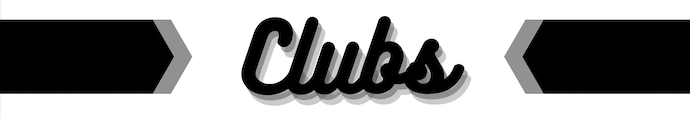

### Mary Allen Wilkes (A)

Mary Allen Wilkes was a computer programmer and logic designer known for her work on LINC, considered by some to be the first mini-computer, a predecessor of the personal computer. Wilkes worked to develop the operating system, which incorporated scrolling and controls to manipulate documents in real time.

### Maryam Mirzakhani (K)

Maryam Mirzakhani was a mathematician who earned the honor of being the first (and as of writing—only) woman to win the [Fields Medal](https://www.mathunion.org/imu-awards/fields-medal), the most prestigious award in the field of mathematics, for her work on advanced geometry.

### Mollie Orshansky (Q)

Mollie Orshansky was a statistician and economist. She developed the [*Orshansky Poverty Thresholds*](https://aspe.hhs.gov/topics/poverty-economic-mobility/poverty-guidelines/further-resources-poverty-measurement-poverty-lines-their-history/history-poverty-thresholds), now used in the United States to determine which households are considered to be poor, based on the cost of a nutritionally sufficient diet.

### Nan Laird (J)

[Nan Laird](https://projecteuclid.org/journals/statistical-science/volume-30/issue-4/A-Conversation-with-Nan-Laird/10.1214/15-STS528.full?tab=ArticleLink) has produced many influential papers in the field of biostatistics. She is most known for writings on the expectation-maximization algorithm, a method to find local maxima and minima for statistical model parameters.

### Nancy Reid (10)

[Nancy Reid](https://utstat.toronto.edu/reid/html/overview.html) is a theoretical statistician, known for her contributions to the theory of statistical inference, profile likelihood, and approximations to significance functions. Her work has also focused on the interaction between Bayesian and frequentest methodologies.

### Radia Perlman (9)

Radia Perlman is a programmer and network engineer, known for inventing the [spanning-tree protocol](https://www.juniper.net/documentation/us/en/software/junos/stp-l2/topics/topic-map/spanning-tree-overview.html), which is essential to allowing for the merging of multiple communication networks.

### Ruth Teitelbaum (8)

Ruth Teitelbaum was one of the first ever computer programmers, working to develop the ENIAC. Having previously spent time manually calculating ballistic trajectories, she worked to develop software that would do this for her and help work to end the era of manual computing.

### Shafi Goldwasser (7)

Shafi Goldwasser has had a big impact in the world of cybersecurity, co-inventing [probabilistic encryption](https://www.google.com/url?sa=t&rct=j&q=&esrc=s&source=web&cd=&ved=2ahUKEwjy5OCTmYTyAhVPVc0KHQgzCA8QFjAPegQILhAD&url=https%3A%2F%2Fhrcak.srce.hr%2Ffile%2F8172&usg=AOvVaw2BsrpLd6tZoXMf76LNVBWo), which set up what is now the gold standard for encryption methodology. She has also done work in complexity theory, helping to classify approximation problems.

### Sofya Kovalevskaya (6)

[Sofya Kovalevskaya](https://www.britannica.com/biography/Sofya-Vasilyevna-Kovalevskaya) was a 19th century mathematician who contributed to the fields of analysis, partial differential equations, and mechanics. She was also the first female editor of a scientific journal and the first woman to become a full professor in northern Europe.

### Sophie Wilson (4)

Sophie Wilson is a computer scientist who worked to design the [BBC Micro](https://computerhistory.org/blog/the-bbc-micro/) (a set of microcomputers and peripherals made for a computer literacy project by the British Broadcasting Corporation) and ARM architecture for computer processors.

### Steve Shirley (3)

[Dame Stephanie “Steve” Shirley](https://www.unssc.org/about-unssc/speakers-and-collaborators/dame-stephanie-steve-shirley/) was a big promoter of workplace equality in her career, working to build a tech empire in the 1960s with an all-female and work-from-home staff from women who had left their careers after becoming mothers. She promoted return to work, flexibile work policy, and ideas of profit-sharing and job-sharing.

### Winifred Edgerton Merrill (2)

[Winifred Edgerton Merrill](https://www.ams.org/notices/201204/rtx120400504p.pdf) was the first American woman to earn a Ph.D. in mathematics, which she received from Columbia in 1886. Later on, she helped draft proposals for the foundation of Barnard College, which was New York City’s first secular higher education institution to offer women a degree in liberal arts.